# Project - Predictive Modeling

### Boxplot for All Continuous Varibales

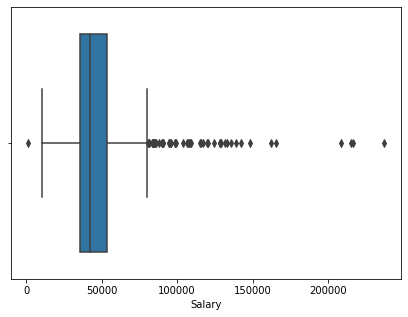

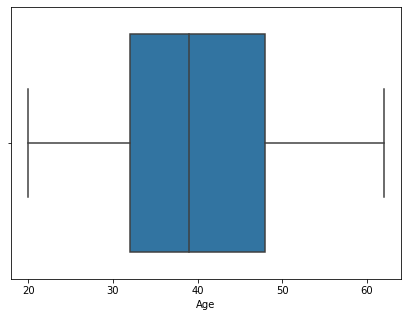

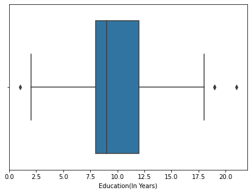

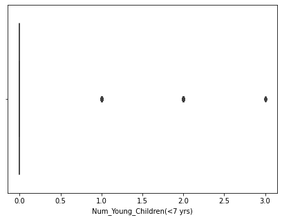

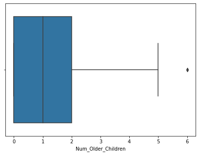

```python
columns = ['Salary','Age','Education(In Years)','Num_Young_Children(<7 yrs)','Num_Older_Children']
for i in columns:
    plt.figure(figsize=(7,5))
    sns.boxplot(holiday[i])
    plt.show();
```

### Treating Outliers

```python
#We will only treat outliers from 'Salary' and 'Education'

def remove_outlier(col):
    sorted(col)
    Q1,Q3=np.percentile(col,[25,75])
    IQR=Q3-Q1
    lower_range= Q1-(1.5 * IQR)
    upper_range= Q3+(1.5 * IQR)
    return lower_range, upper_range
```

```python
cont_variables = ['Salary','Education(In Years)']

for column in holiday[cont_variables].columns:
    lr,ur=remove_outlier(holiday[column])
    holiday[column]=np.where(holiday[column]>ur,ur,holiday[column])
    holiday[column]=np.where(holiday[column]<lr,lr,holiday[column])
```

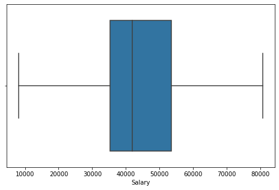

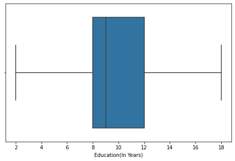

```python
for k in cont_variables:
    plt.figure(figsize=(8,5))
    sns.boxplot(holiday[k])
    plt.show()
```

Now Outliers are removed from the above columns.

### Catplots:

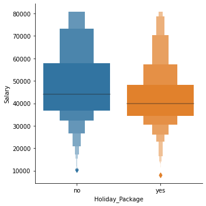

```python
#Catplot for 'foreign' with respect to 'Salary'

sns.catplot(x='Holiday_Package', y='Salary',data=holiday, kind='boxen')
```

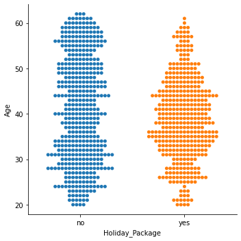

```python
#Catplot for 'Holiday_Package' with respect to 'Age'

sns.catplot(x="Holiday_Package", y="Age",data=holiday, kind="swarm")
```

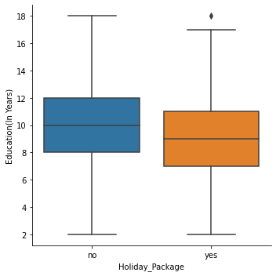

```python
sns.catplot(x="Holiday_Package", y="Education(In Years)",data=holiday, kind="box")
```

### Pairplot:

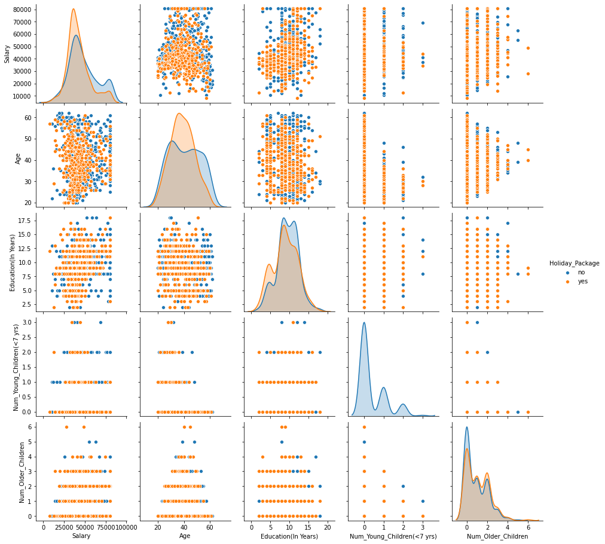

```python
sns.pairplot(data=holiday ,hue='Holiday_Package', diag_kind='kde');
```

### Heatmap and Correlation

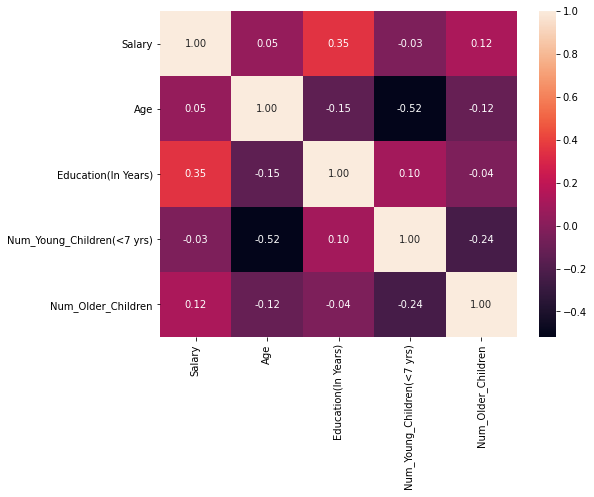

```python
holiday_corr = holiday.corr()
plt.figure(figsize=(8,6))
sns.heatmap(holiday_corr, annot=True, fmt = '.2f')
```

There isn't any strong correlation in the data.

## 2.2 Do not scale the data. Encode the data (having string values) for Modelling. Data Split: Split the data into train and test (70:30). Apply Logistic Regression and LDA (linear discriminant analysis).

```python
#Let's first keep the original dataframe separate

df = holiday.copy()

df.head()
```

|  | Holiday_Package | Salary | Age | Education(In Years) | Num_Young_Children(<7 yrs) | Num_Older_Children | Foreign |
| --- | --- | --- | --- | --- | --- | --- | --- |
| 1 | no | 48412.0 | 30 | 8.0 | 1 | 1 | no |
| 2 | yes | 37207.0 | 45 | 8.0 | 0 | 1 | no |
| 3 | no | 58022.0 | 46 | 9.0 | 0 | 0 | no |
| 4 | no | 66503.0 | 31 | 11.0 | 2 | 0 | no |
| 5 | no | 66734.0 | 44 | 12.0 | 0 | 2 | no |

```python
#Get dummies

dummy_df = pd.get_dummies(df, columns=['Holiday_Package','Foreign'], drop_first = True)
```

```python
dummy_df.head()
```

|  | Salary | Age | Education(In Years) | Num_Young_Children(<7 yrs) | Num_Older_Children | Holiday_Package_yes | Foreign_yes |
| --- | --- | --- | --- | --- | --- | --- | --- |
| 1 | 48412.0 | 30 | 8.0 | 1 | 1 | 0 | 0 |
| 2 | 37207.0 | 45 | 8.0 | 0 | 1 | 1 | 0 |
| 3 | 58022.0 | 46 | 9.0 | 0 | 0 | 0 | 0 |
| 4 | 66503.0 | 31 | 11.0 | 2 | 0 | 0 | 0 |
| 5 | 66734.0 | 44 | 12.0 | 0 | 2 | 0 | 0 |

```python
dummy_df.shape
```

```
(872, 7)
```

```python
dummy_df.columns
```

```
Index(['Salary', 'Age', 'Education(In Years)', 'Num_Young_Children(<7 yrs)',
       'Num_Older_Children', 'Holiday_Package_yes', 'Foreign_yes'],
      dtype='object')
```

### Splitting into train and test set

```python
#Holiday_Package_yes is the Target variable

X = dummy_df.drop('Holiday_Package_yes', axis=1)
y = dummy_df['Holiday_Package_yes']


X_train, X_test, y_train, y_test = train_test_split(X, y, test_size=0.30 , random_state=1,stratify=y)
```

```python
y_train.value_counts(1)
```

```
0    0.539344
1    0.460656
Name: Holiday_Package_yes, dtype: float64
```

```python
y_test.value_counts(1)
```

```
0    0.541985
1    0.458015
Name: Holiday_Package_yes, dtype: float64
```

### Let's now build the Logistic Regression Model:

We are making some adjustments to the parameters in the Logistic Regression Class to get a better accuracy.

```python
#We will use GridSearchCV for getting the best parameters for the model

from sklearn.model_selection import GridSearchCV

grid={'penalty':['l1','l2','none'], 'solver':['lbfgs', 'liblinear'], 'tol':[0.0001,0.000001]}
```

```python
# Fit the Logistic Regression model

model = LogisticRegression(max_iter=100000,n_jobs=2)

grid_search = GridSearchCV(estimator = model, param_grid = grid, cv = 3,n_jobs=-1,scoring='f1')
```

```python
grid_search.fit(X_train, y_train)
```

```
GridSearchCV(cv=3, estimator=LogisticRegression(max_iter=100000, n_jobs=2),
             n_jobs=-1,
             param_grid={'penalty': ['l1', 'l2', 'none'],
                         'solver': ['lbfgs', 'liblinear'],
                         'tol': [0.0001, 1e-06]},
             scoring='f1')
```

```python
#Getting the best parameters and best grid estimators:

grid_search.best_params_
```

```
{'penalty': 'l1', 'solver': 'liblinear', 'tol': 1e-06}
```

```python
best_model = grid_search.best_estimator_
best_model
```

```
LogisticRegression(max_iter=100000, n_jobs=2, penalty='l1', solver='liblinear',
                   tol=1e-06)
```

### Predicting on Training and Test dataset

```python
ytrain_predict = best_model.predict(X_train)
ytest_predict = best_model.predict(X_test)
```

```python
## Getting the probabilities on the test set

ytest_predict_prob = best_model.predict_proba(X_test)
```

```python
#Checking the head from the predicted probability

pd.DataFrame(ytest_predict_prob).head(10)
```

|  | 0 | 1 |
| --- | --- | --- |
| 0 | 0.671228 | 0.328772 |
| 1 | 0.560763 | 0.439237 |
| 2 | 0.684892 | 0.315108 |
| 3 | 0.510392 | 0.489608 |
| 4 | 0.560310 | 0.439690 |
| 5 | 0.345337 | 0.654663 |
| 6 | 0.573157 | 0.426843 |
| 7 | 0.303291 | 0.696709 |
| 8 | 0.386480 | 0.613520 |
| 9 | 0.633587 | 0.366413 |

### Confusion Matrix and Classification Report on the Training Data

```
<sklearn.metrics._plot.confusion_matrix.ConfusionMatrixDisplay at 0x28d8622ad00>
```

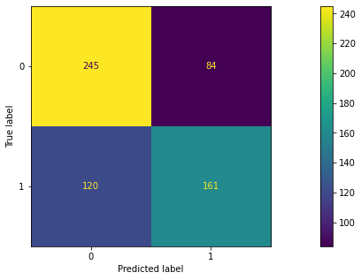

```python
## Confusion matrix on the training data

plot_confusion_matrix(best_model,X_train,y_train)
```

```python
print(classification_report(y_train, ytrain_predict))
```

```
              precision    recall  f1-score   support

           0       0.67      0.74      0.71       329
           1       0.66      0.57      0.61       281

    accuracy                           0.67       610
   macro avg       0.66      0.66      0.66       610
weighted avg       0.66      0.67      0.66       610
```

### Confusion Matrix and Classification Report on Testing Data

```
<sklearn.metrics._plot.confusion_matrix.ConfusionMatrixDisplay at 0x28d817ef2e0>
```

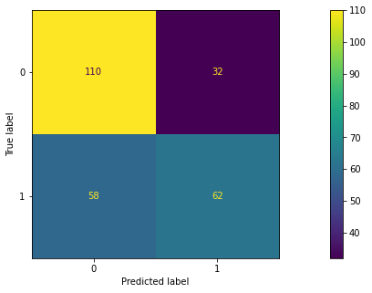

```python
## Confusion matrix on the test data

plot_confusion_matrix(best_model,X_test,y_test)
```

```python
print(classification_report(y_test, ytest_predict))
```

```
              precision    recall  f1-score   support

           0       0.65      0.77      0.71       142
           1       0.66      0.52      0.58       120

    accuracy                           0.66       262
   macro avg       0.66      0.65      0.64       262
weighted avg       0.66      0.66      0.65       262
```

### Model Evaluation

```python
# Accuracy score for training data

acc_train = best_model.score(X_train, y_train)

acc_train
```

```
0.6655737704918033
```

### AUC and ROC for the training data

```python
# predict probabilities

probs = best_model.predict_proba(X_train)
```

```python
# keep probabilities for the positive outcome only

probs = probs[:, 1]
```

```python
# calculate AUC
auc = roc_auc_score(y_train, probs)
print('AUC: %.3f' % auc)
```

```
AUC: 0.733
```

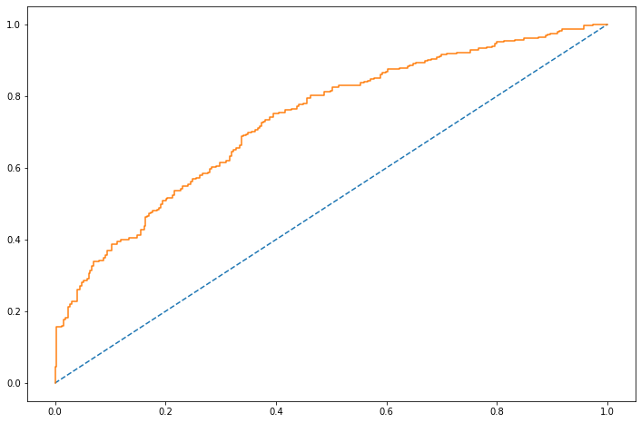

```python
# calculate roc curve

train_fpr, train_tpr, train_thresholds = roc_curve(y_train, probs)
plt.rcParams["figure.figsize"] = (12,8)
plt.plot([0, 1], [0, 1], linestyle='--')
# plot the roc curve for the model
plt.plot(train_fpr, train_tpr);
```

```python
#Accuracy score for test data

acc_test = best_model.score(X_test, y_test)

acc_test
```

```
0.6564885496183206
```

```
AUC: 0.715
```

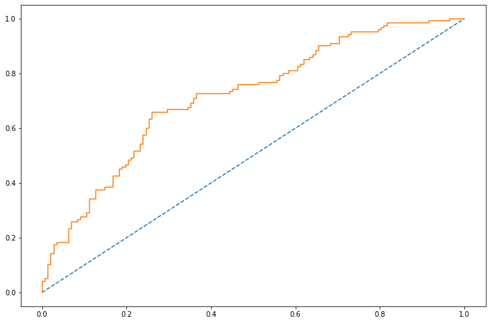

```python
# predict probabilities
probs = best_model.predict_proba(X_test)

# Probabilities for the positive outcome only
probs = probs[:, 1]

# calculate AUC
test_auc = roc_auc_score(y_test, probs)
print('AUC: %.3f' % test_auc)

# calculate roc curve
test_fpr, test_tpr, test_thresholds = roc_curve(y_test, probs)
plt.plot([0, 1], [0, 1], linestyle='--')

# plot the roc curve for the model
plt.plot(test_fpr, test_tpr);
```

### Linear Discriminant Analysis (LDA)

```python
#Let's go back to our original dataframe 'holiday'

holiday_df.head()
```

|  | Holiday_Package | Salary | Age | Education(In Years) | Num_Young_Children(<7 yrs) | Num_Older_Children | Foreign |
| --- | --- | --- | --- | --- | --- | --- | --- |
| 1 | no | 48412 | 30 | 8 | 1 | 1 | no |
| 2 | yes | 37207 | 45 | 8 | 0 | 1 | no |
| 3 | no | 58022 | 46 | 9 | 0 | 0 | no |
| 4 | no | 66503 | 31 | 11 | 2 | 0 | no |
| 5 | no | 66734 | 44 | 12 | 0 | 2 | no |

```python
holiday_df.isnull().sum()
```

```
Holiday_Package               0
Salary                        0
Age                           0
Education(In Years)           0
Num_Young_Children(<7 yrs)    0
Num_Older_Children            0
Foreign                       0
dtype: int64
```

```python
holiday_df.duplicated().sum()
```

```
0
```

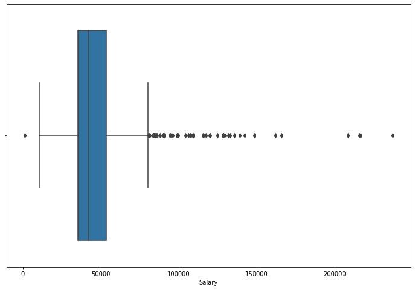

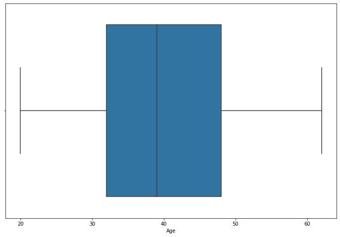

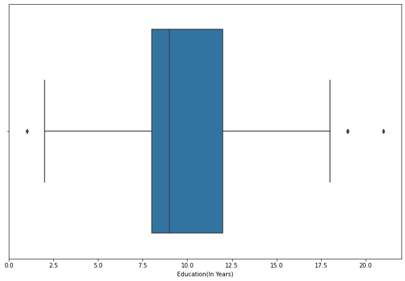

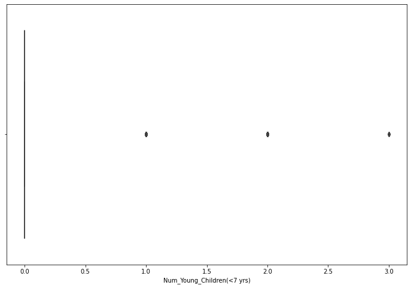

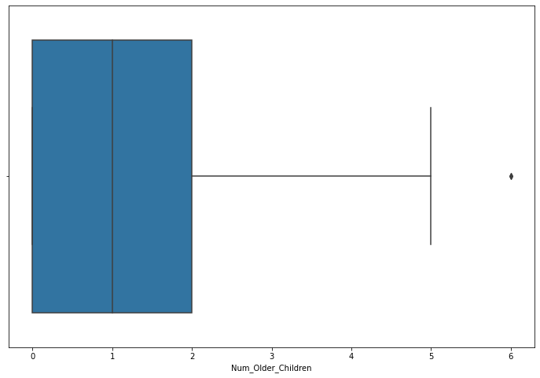

```python
cols = ['Salary' ,'Age', 'Education(In Years)', 'Num_Young_Children(<7 yrs)', 'Num_Older_Children']

for i in cols:
    sns.boxplot(holiday_df[i])
    plt.show()
```

```python
#Treating Outliers:

def remove_outlier(col):
    sorted(col)
    Q1,Q3=np.percentile(col,[25,75])
    IQR=Q3-Q1
    lower_range= Q1-(1.5 * IQR)
    upper_range= Q3+(1.5 * IQR)
    return lower_range, upper_range
```

```python
cont_variables = ['Salary' ,'Age', 'Education(In Years)', 'Num_Young_Children(<7 yrs)', 'Num_Older_Children']

for column in holiday_df[cont_variables].columns:
    lr,ur=remove_outlier(holiday_df[column])
    holiday_df[column]=np.where(holiday_df[column]>ur,ur,holiday[column])
    holiday_df[column]=np.where(holiday_df[column]<lr,lr,holiday[column])
```

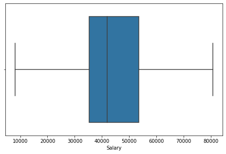

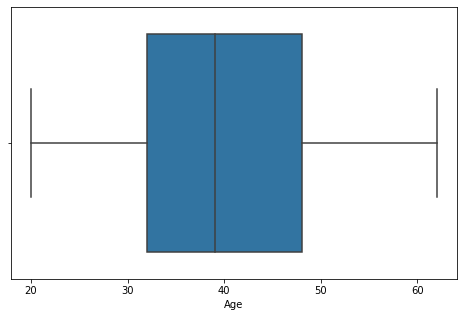

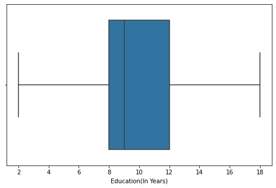

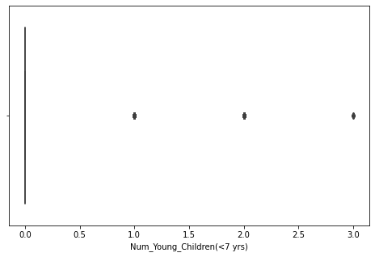

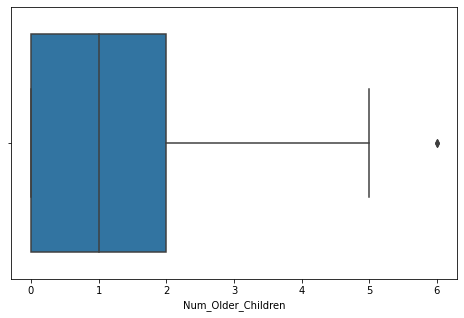

```python
for k in cont_variables:
    plt.figure(figsize=(8,5))
    sns.boxplot(holiday_df[k])
    plt.show()
```

```python
for i in holiday_df.columns:
    if holiday_df[i].dtype == 'object':
        print('\n')
        print('Column:',i)
        print(pd.Categorical(holiday_df[i].unique()))
        print(pd.Categorical(holiday_df[i].unique()).codes)
        holiday_df[i] = pd.Categorical(holiday_df[i]).codes
```

```
Column: Holiday_Package
[no, yes]
Categories (2, object): [no, yes]
[0 1]


Column: Foreign
[no, yes]
Categories (2, object): [no, yes]
[0 1]
```

### Splitting the data into train and test sets for the LDA model

```python
from sklearn.discriminant_analysis import LinearDiscriminantAnalysis
from sklearn import metrics, model_selection
from sklearn.preprocessing import scale
```

```python
X = holiday_df.drop('Holiday_Package',axis=1)
Y = holiday_df.pop('Holiday_Package')
```

```python
from sklearn.model_selection import train_test_split,GridSearchCV

X_train,X_test,Y_train,Y_test = train_test_split(X,Y,test_size=0.30,random_state=1,stratify = Y)
```

```python
X_train.head()
```

|  | Salary | Age | Education(In Years) | Num_Young_Children(<7 yrs) | Num_Older_Children | Foreign |
| --- | --- | --- | --- | --- | --- | --- |
| 822 | 38974.0 | 47.0 | 12.0 | 0.0 | 2.0 | 1 |
| 806 | 40270.0 | 33.0 | 8.0 | 2.0 | 0.0 | 1 |
| 323 | 32573.0 | 30.0 | 11.0 | 1.0 | 0.0 | 0 |
| 702 | 43839.0 | 43.0 | 11.0 | 0.0 | 1.0 | 1 |
| 774 | 33060.0 | 40.0 | 5.0 | 1.0 | 1.0 | 1 |

### Let's build the LDA Model:

```python
clf = LinearDiscriminantAnalysis()

LDA_model=clf.fit(X_train,Y_train)
```

```python
#Train data class prediction
#cut off value is 0.5

pred_class_train = LDA_model.predict(X_train)
```

```python
# Test data class prediction
#cut-off value is 0.5

pred_class_test = LDA_model.predict(X_test)
```

### 2.3 Performance Metrics: Check the performance of Predictions on Train and Test sets using Accuracy, Confusion Matrix, Plot ROC curve and get ROC_AUC score for each model Final Model: Compare Both the models and write inference which model is best/optimized.

### Comparison between train and test Confusion matrix

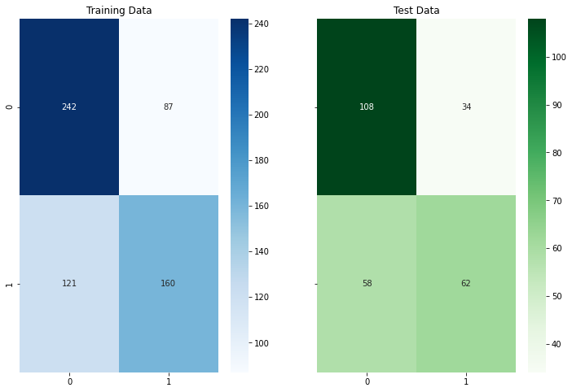

```python
f,a =  plt.subplots(1,2,sharex=True,sharey=True,squeeze=False)

#Plotting confusion matrix for the different models for the Training Data

plot_0 = sns.heatmap((metrics.confusion_matrix(Y_train,pred_class_train)),annot=True,fmt='.5g',cmap='Blues',ax=a[0][0]);
a[0][0].set_title('Training Data')

plot_1 = sns.heatmap((metrics.confusion_matrix(Y_test,pred_class_test)),annot=True,fmt='.5g',cmap='Greens',ax=a[0][1]);
a[0][1].set_title('Test Data');
```

### Classification Report comparison

```python
print('Classification Report of the training data:\n\n',metrics.classification_report(Y_train,pred_class_train),'\n')
print('Classification Report of the test data:\n\n',metrics.classification_report(Y_test,pred_class_test),'\n')
```

```
Classification Report of the training data:

               precision    recall  f1-score   support

           0       0.67      0.74      0.70       329
           1       0.65      0.57      0.61       281

    accuracy                           0.66       610
   macro avg       0.66      0.65      0.65       610
weighted avg       0.66      0.66      0.66       610


Classification Report of the test data:

               precision    recall  f1-score   support

           0       0.65      0.76      0.70       142
           1       0.65      0.52      0.57       120

    accuracy                           0.65       262
   macro avg       0.65      0.64      0.64       262
weighted avg       0.65      0.65      0.64       262
```